# Environics Case Study

Athira

2025-06-25

# 1 Initial Analysis based on Target Groups: Demographic Summary & Purchasing Details

## 1.1 Based on declining sales from Wander Luxe Matrix- 2023-2024 we can list 3 groups

- Timeless Trends- 17-12% -5% Decrease Average Annual Expenditure decline-295
- Heights of Style- 15-10% -5% Decrease Average Annual Expenditure decline-167
- Country Chic- 13-12% -1% decrease Average Annual Expenditure-151 increase

So based on this Analysis I am picking **Timeless Trends** for our Analystical study

```r
library(readxl)
library(dplyr)
```

```r
#import the file
envronics<-read_excel("EnvironicsAnalytics_Supplementary_DemoStats - Target Group.xlsx",skip = 3)
View(envronics)
library(ggplot2)
# Counting the Timeless Index, where index is more than average
More_than_average_Timeless_Index_count<-sum(envronics$`Timeless Trends_Index`>100)
print(More_than_average_Timeless_Index_count)
```

```
## [1] NA
```

```r
#Getting the dataset with Timeless Index  is more than average and Plot that using ggplot
Timeless_Index_Higher_details<-envronics %>%
                               select(Features,Timeless_Trends_Count,`Timeless Trends%`,`Timeless Trends% Pen`,`Timeless Trends_Index`) %>%
                              filter(envronics$`Timeless Trends_Index`>100)
print(Timeless_Index_Higher_details)
```

```
## # A tibble: 60 × 5
##    Features      Timeless_Trends_Count `Timeless Trends%` `Timeless Trends% Pen`
##    <chr>         <chr>                              <dbl> <chr>
##  1 45 to 54      138278                             18.0  5.08
##  2 55 to 64      164666                             21.4  5.54
##  3 65 to 74      157312                             20.4  6.05
##  4 75 To 84      101621                             13.2  6.76
##  5 85 Or Older   32857                               4.27 6.96
##  6 2 Persons     286259                             37.2  5.24
##  7 3 Persons     127284                             16.5  5.44
##  8 4 Persons     140059                             18.2  6.56
##  9 5 or More Pe… 75422                               9.8  5.51
## 10 Total Family… 602923                             78.3  5.76
## # ℹ 50 more rows
## # ℹ 1 more variable: `Timeless Trends_Index` <dbl>
```

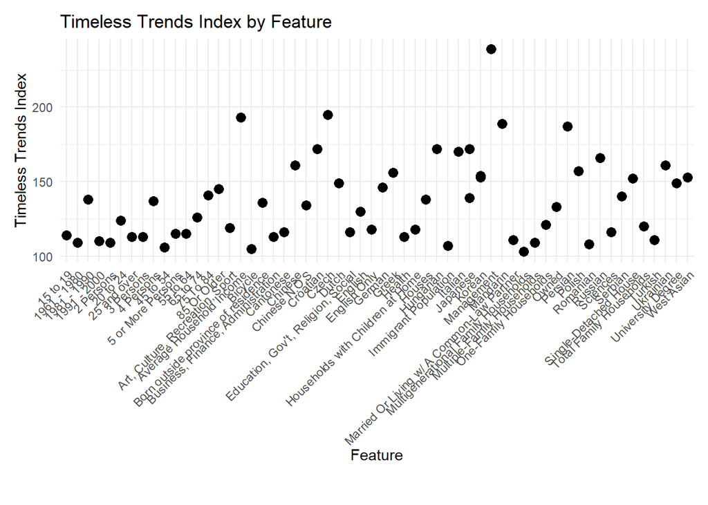

```r
#Inference from plot
#We are anlyzing timeless trend Index.
#We are checking on values more than average index(>100)
#We could see like Management people has more than 200 index
#We could also infer like Czech people,Mandreain speaking people,-
#persian people and people having average house hold income lies in the 150-200 range
ggplot(Timeless_Index_Higher_details, aes(x=Features,y=`Timeless Trends_Index`)) +
  geom_point(fill = "lightgreen", color = "black",size=3) +
  theme_minimal() +
  theme(
    axis.text.x = element_text(angle = 45, hjust = 1),
    plot.margin = margin(10, 10, 30, 10)
  ) +
  labs(
    title = "Timeless Trends Index by Feature",
    x = "Feature",
    y = "Timeless Trends Index")
```

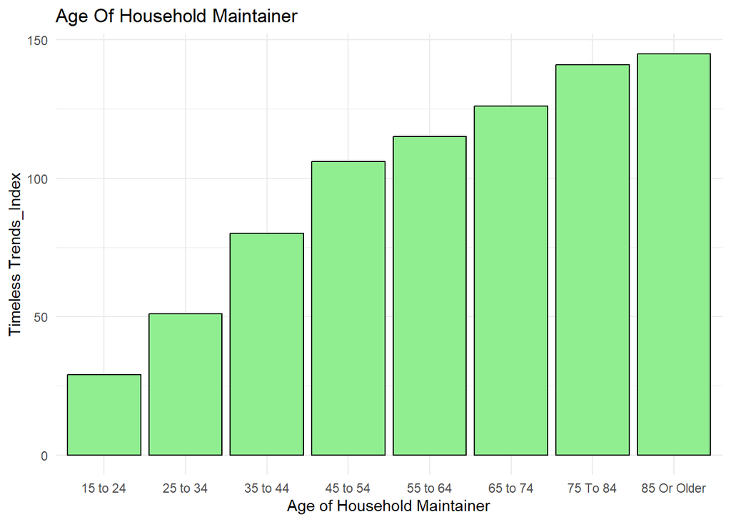

```r
#creating a dataset with Age of Household Maintainer
Age_of_household_maintainer<-filter(envronics, Features %in% c("15 to 24","25 to 34",
"35 to 44","45 to 54","55 to 64","65 to 74","75 To 84","85 Or Older"))
#Plot the graph
#Inference from Graph
#85 or Older is having higher Index and we can also see the trend of increasing Timeless tend index with age
ggplot(Age_of_household_maintainer, aes(x=Features,y=`Timeless Trends_Index`)) +
  geom_col(fill = "lightgreen", color = "black") +
 labs(title = "Age Of Household Maintainer",
   x = "Age of Household Maintainer")+
   #    y = "Passenger Count")
  theme_minimal()
```

```r
#Getting the count of higher average index based on Age of household maintainer
More_than_average_age_Househld_maintainer=0
More_than_average_age_Househld_maintainer<-sum(Age_of_household_maintainer$`Timeless Trends_Index`>100)
print(More_than_average_age_Househld_maintainer)
```

```
## [1] 5
```

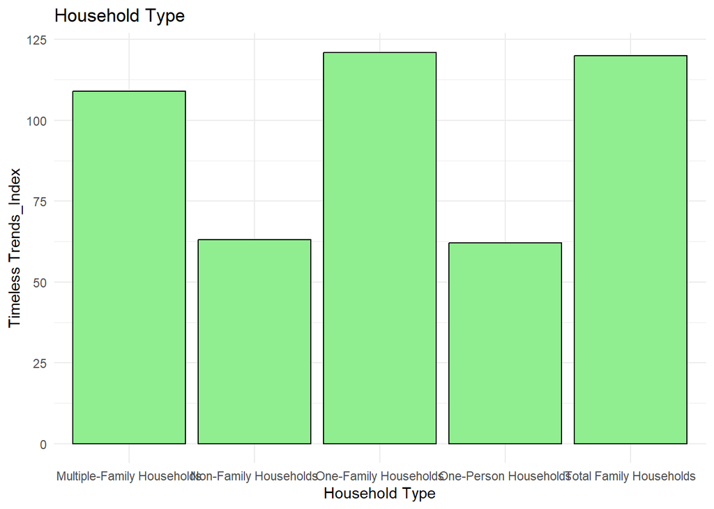

```r
#Creating a dataframe with house hold type
Household_Type<- filter(envronics,Features %in% c("Total Family Households","One-Family Households","Multigenerational Family Households
","Multiple-Family Households","Non-Family Households","One-Person Households","Two-Or-More-Person Households
"))
#Inference:-One family household is having high index
ggplot(Household_Type, aes(x=Features,y=`Timeless Trends_Index`)) +
  geom_col(fill = "lightgreen", color = "black") +
  labs(title = "Household Type",
       x = "Household Type")+
  #    y = "Passenger Count")
  theme_minimal()
```

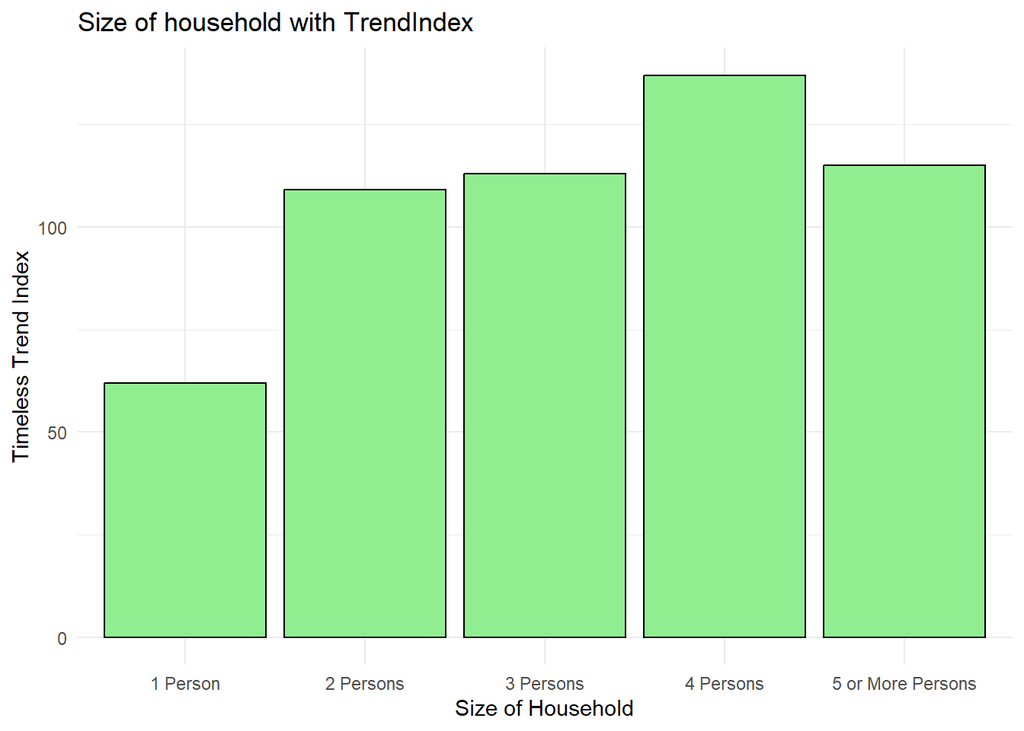

```r
#Creating a dataset with Size of household
Size_of_household <- filter(envronics, Features %in% c("1 Person","2 Persons","3 Persons","4 Persons","5 or More Persons"))

#from the plot bellow we could infer like 4 person famiy having high index
ggplot(Size_of_household, aes(x=Features,y=`Timeless Trends_Index`)) +
  geom_col(fill = "lightgreen", color = "black") +
  labs(title = "Size of household with TrendIndex",
       x = "Size of Household",
      y = "Timeless Trend Index") +
  theme_minimal()
```

```r
#Counting the higher timeless trend Index based on Size of Household
More_than_avrg_size_of_household<-sum(Size_of_household$`Timeless Trends_Index`>100)
print(More_than_avrg_size_of_household)
```

```
## [1] 4
```

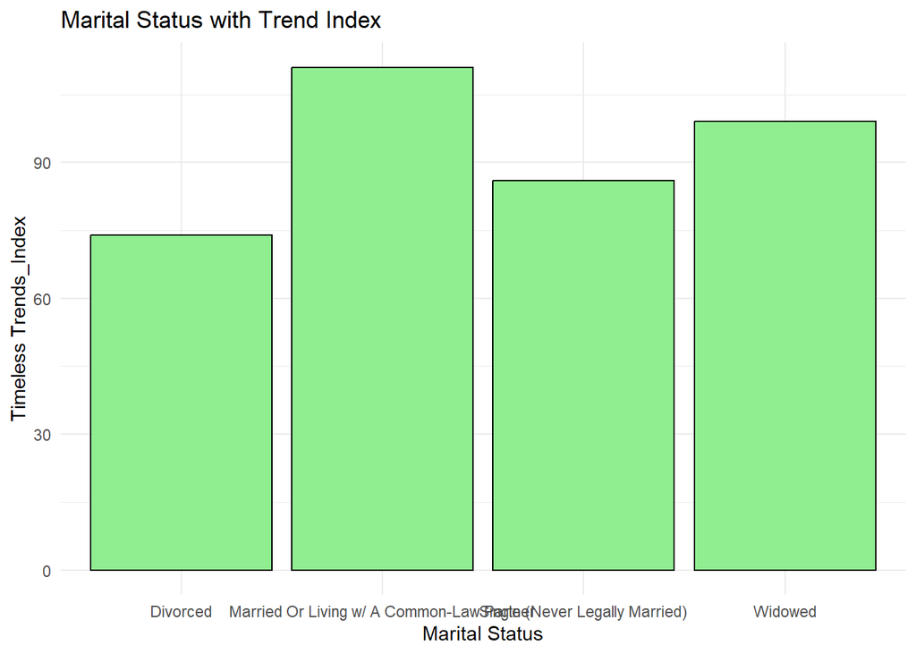

```r
#Creating a dataset with Marital status
Marital_Status<-filter(envronics,Features %in% c("Married Or Living w/ A Common-Law Partner","Single (Never Legally Married)","Separated
","Divorced","Widowed"))
#from the graph bellow we could infer like Married or leaving with a common low partner has greater value of index
ggplot(Marital_Status, aes(x=Features,y=`Timeless Trends_Index`)) +
  geom_col(fill = "lightgreen", color = "black") +
  labs(title = "Marital Status with Trend Index",
     x = "Marital Status")+
  #    y = "Passenger Count")
  theme_minimal()
```

```r
#Counting the higher timeless trend Index based on Marital Status
More_than_average_Marital_Status<-sum(Marital_Status$`Timeless Trends_Index`>100)
print(More_than_average_Marital_Status)
```

```
## [1] 1
```

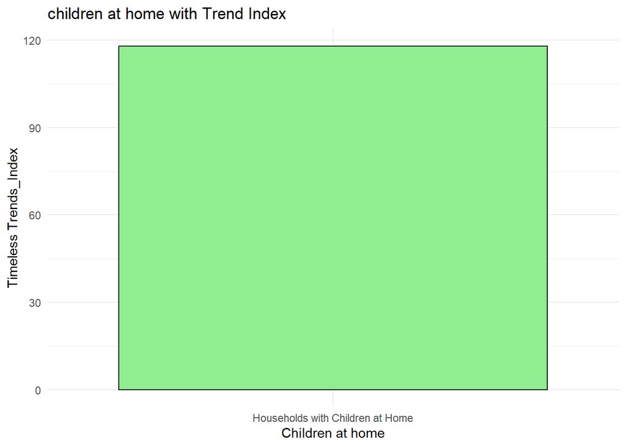

```r
#Inference from bellow plot is that, household with children at home is having more than average Timeless Index
Children_at_Home<-filter(envronics,Features %in% c("Households with Children at Home"))
ggplot(Children_at_Home, aes(x=Features,y=`Timeless Trends_Index`)) +
  geom_col(fill = "lightgreen", color = "black") +
  labs(title = "children at home with Trend Index",
       x = "Children at home")+
  #    y = "Passenger Count")
  theme_minimal()
```

```r
More_than_average_children_at_home<-sum(Children_at_Home$`Timeless Trends_Index`>100)
print(More_than_average_children_at_home)
```

```
## [1] 1
```

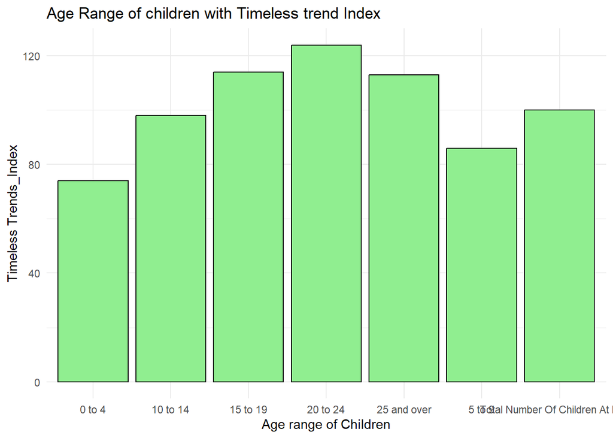

```r
#Created a Dataframe with age of children at home
Age_of_Children_at_Home<-filter(envronics,Features %in% c("Total Number Of Children At Home",
"0 to 4",
"5 to 9",
"10 to 14",
"15 to 19",
"20 to 24",
"25 and over"
))
#Inference from Plot
#20-24 age range is the children having highest Timeless Trend Index
ggplot(Age_of_Children_at_Home, aes(x=Features,y=`Timeless Trends_Index`)) +
  geom_col(fill = "lightgreen", color = "black") +
  labs(title = "Age Range of children with Timeless trend Index",
   x = "Age range of Children")+
  #    y = "Passenger Count")
  theme_minimal()
```

```r
#count of Timeless trend index having more than average value is listed
More_than_average_age_children_at_home<-sum(Age_of_Children_at_Home$`Timeless Trends_Index`>100)
print(More_than_average_age_children_at_home)
```

```
## [1] 3
```

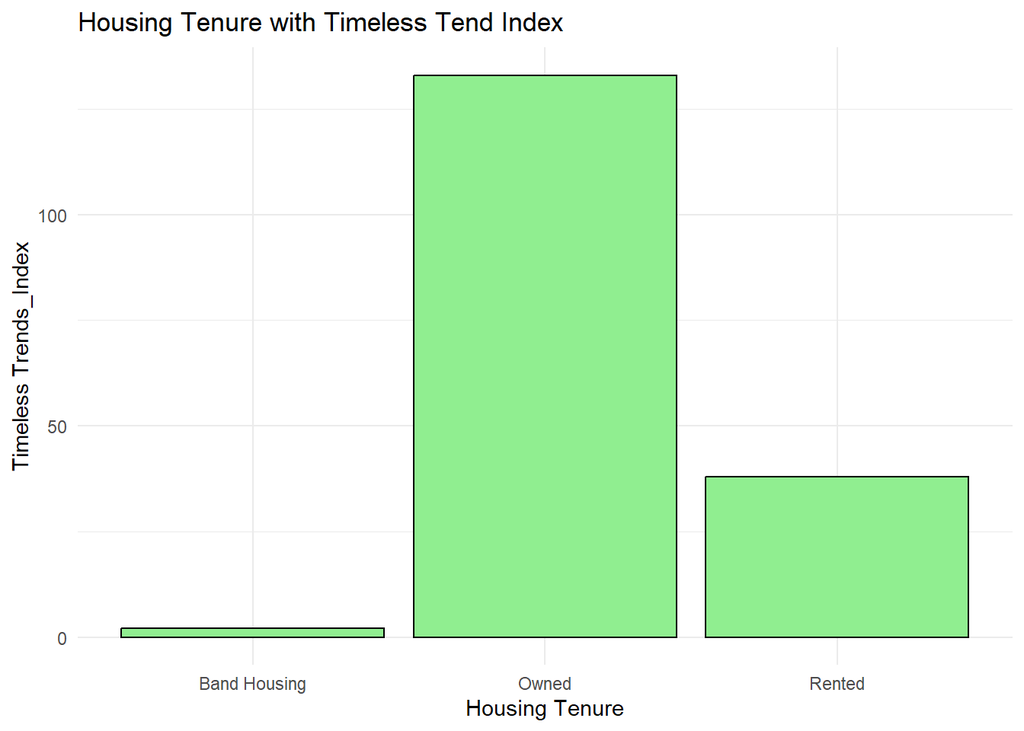

```r
# creating a dataset with Housing Tenure details
Housing_Tenure<-filter(envronics,Features %in% c("Owned",
                                                 "Rented","Band Housing"))
#Inference from Plot
#We can see person who owned the house is having higher Timeless Trend Index
ggplot(Housing_Tenure, aes(x=Features,y=`Timeless Trends_Index`)) +
  geom_col(fill = "lightgreen", color = "black") +
  labs(title = "Housing Tenure with Timeless Tend Index",
     x = "Housing Tenure")+
  #    y = "Passenger Count")
  theme_minimal()
```

```r
#count of Timeless trend index having more than average value in this group is listed
More_than_avg_housing_tenur<-sum(Housing_Tenure$`Timeless Trends_Index`>100)
print(More_than_avg_housing_tenur)
```

```
## [1] 1
```

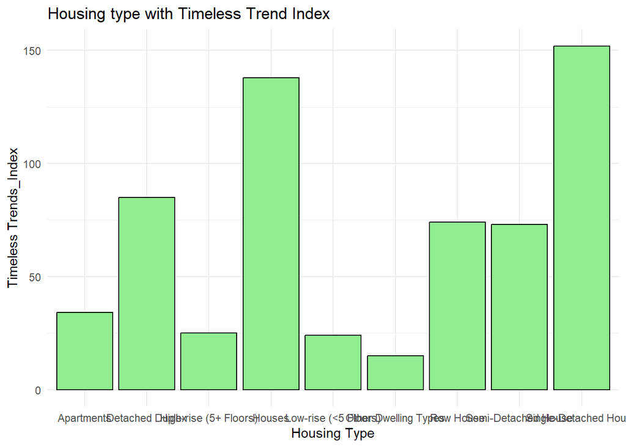

```r
#Creating a dataset with Housing Type
Housing_Type<-filter(envronics, Features %in% c("Houses",
                                                "Single-Detached House",
                                                "Semi-Detached House",
                                                "Row House",
                                                "Apartments",
                                                "High-rise (5+ Floors)",
                                                "Low-rise (<5 Floors)",
                                                "Detached Duplex",
                                                "Other Dwelling Types"
))
#Ploting graph
#Person with single Detached house is having higher Timeless Trend index
ggplot(Housing_Type, aes(x=Features,y=`Timeless Trends_Index`)) +
  geom_col(fill = "lightgreen", color = "black") +
  labs(title = "Housing type with Timeless Trend Index",
    x = "Housing Type") +
  #    y = "Passenger Count")
  theme_minimal()
```

```r
#count of Timeless trend index having more than average value in this group is listed
More_than_avg_house_type<-sum(Housing_Type$`Timeless Trends_Index`>100)
print(More_than_avg_house_type)
```

```
## [1] 2
```

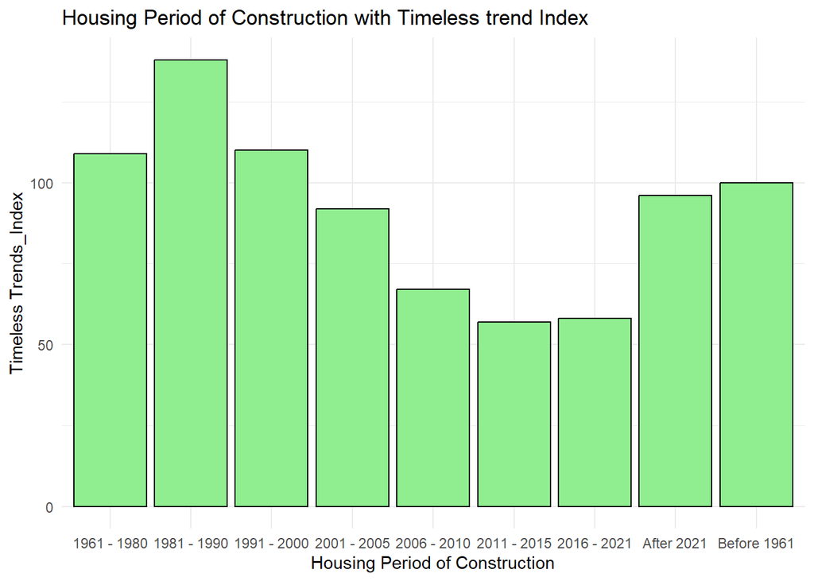

```r
#Creating a Dataset with Housing period of Construction details
Housing_Period_of_Construction<-filter(envronics,Features %in% c("Before 1961",
                                                                 "1961 - 1980",
                                                                 "1981 - 1990",
                                                                 "1991 - 2000",
                                                                 "2001 - 2005",
                                                                 "2006 - 2010",
                                                                 "2011 - 2015",
                                                                 "2016 - 2021",
                                                                 "After 2021"
))
# 1981-90 housing constructed people have higher Timeless trend index
ggplot(Housing_Period_of_Construction, aes(x=Features,y=`Timeless Trends_Index`)) +
  geom_col(fill = "lightgreen", color = "black") +
  labs(title = "Housing Period of Construction with Timeless trend Index",
  x = "Housing Period of Construction")+
  #    y = "Passenger Count")
  theme_minimal()
```

```r
#count of Timeless trend index having more than average value in this group is listed
More_than_avg_housing_construction<-sum(Housing_Period_of_Construction>100)
print(More_than_avg_housing_construction)
```

```
## [1] 130
```

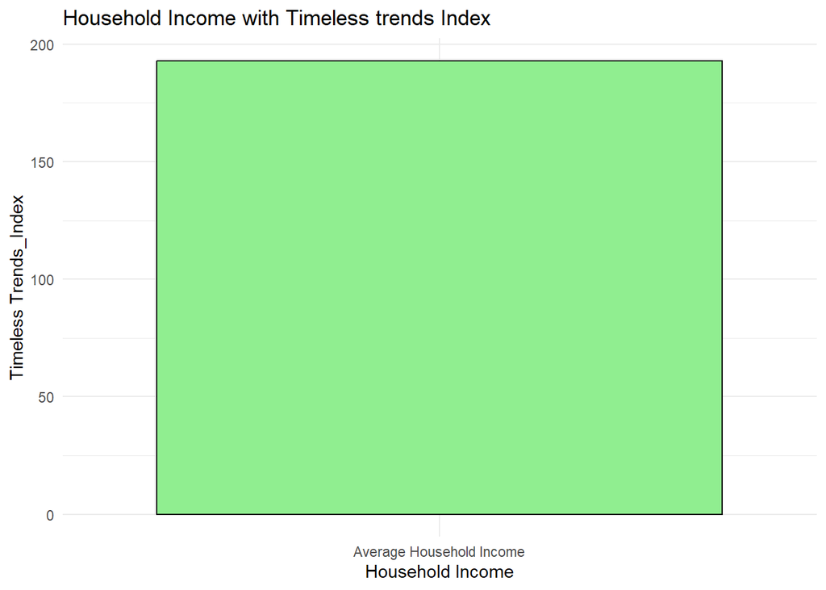

```r
#Created dataset with household Income
Household_Income<-filter(envronics,Features %in% c("Average Household Income"))
#Plot a graph
#Graph shows Timeless Trend Index is nearly equal to 200, which is so high
ggplot(Household_Income, aes(x=Features,y=`Timeless Trends_Index`)) +
  geom_col(fill = "lightgreen", color = "black") +
  labs(title = "Household Income with Timeless trends Index",
 x = "Household Income")+
  #    y = "Passenger Count")
  theme_minimal()
```

```r
#count of Timeless trend index having more than average value in this group is listed
More_than_average_household_income<-sum(Household_Income$`Timeless Trends_Index`>100)
print(More_than_average_household_income)
```

```
## [1] 1
```

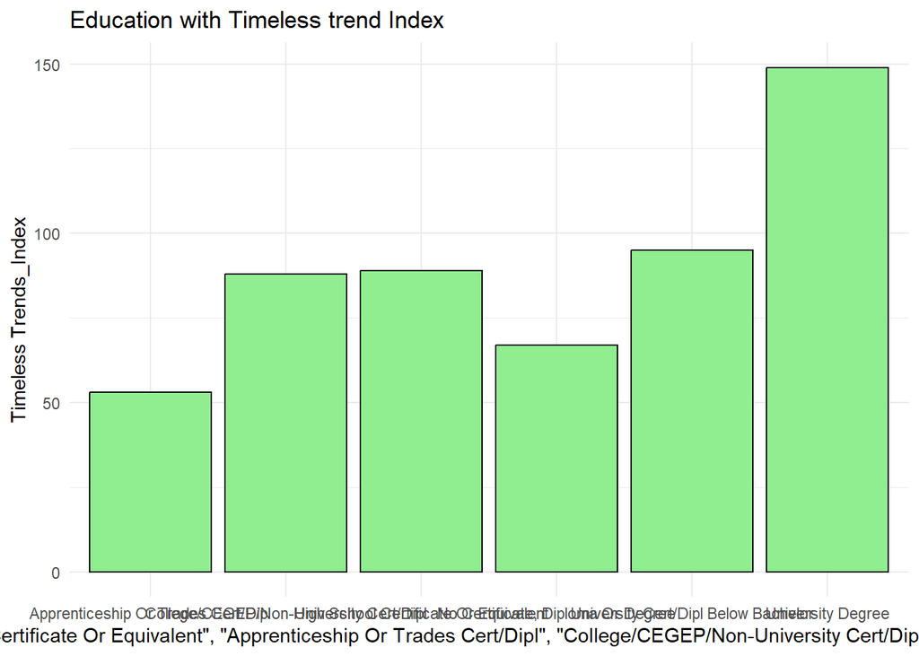

```r
#Created a dataset with education details
Education<-filter(envronics,Features %in% c("No Certificate, Diploma Or Degree",
                                            "High School Certificate Or Equivalent",
                                            "Apprenticeship Or Trades Cert/Dipl",
                                            "College/CEGEP/Non-University Cert/Dipl",
                                            "University Cert/Dipl Below Bachelor",
                                            "University Degree"
))
#After ploting we could see like a person ith University degree is having highest Timeless Trend Index
ggplot(Education, aes(x=Features,y=`Timeless Trends_Index`)) +
  geom_col(fill = "lightgreen", color = "black") +
  labs(title = "Education with Timeless trend Index",
  x = Education)+
  #    y = "Passenger Count")
  theme_minimal()
```

```r
#count of Timeless trend index having more than average value in this group is listed
More_Than_average_Education<-sum(Education$`Timeless Trends_Index`>100)
print(More_Than_average_Education)
```

```
## [1] 1
```

```r
#Created a dataset with Labour force details
Labour_Force<-filter(envronics,Features %in% c("In The Labour Force (15+)"))
More_than_avg_Labour_Force<-sum(Labour_Force$`Timeless Trends_Index`>100)
print(More_than_avg_Labour_Force)
```

```
## [1] 0
```

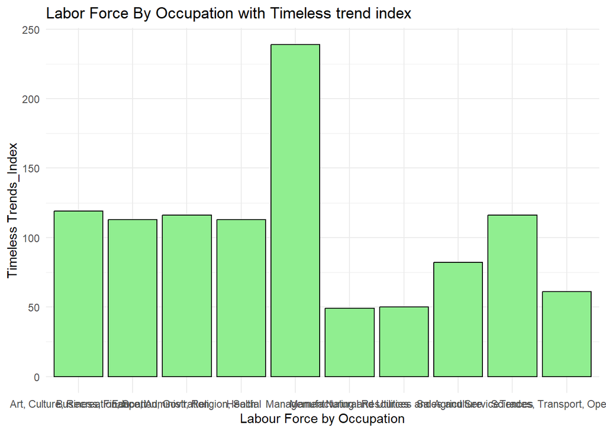

```r
#Created a dataset with Labour force details
Labour_Force_by_Occupation<-filter(envronics,Features %in% c("Management",
                                                             "Business, Finance, Administration",
                                                             "Sciences",
                                                             "Health",
                                                             "Education, Gov't, Religion, Social",
                                                             "Art, Culture, Recreation, Sport",
                                                             "Sales and Service",
                                                             "Trades, Transport, Operators",
                                                             "Natural Resources and Agriculture",
                                                             "Manufacturing and Utilities"
))
#From plot we can see like Management people is having higher Timeless trend Index
ggplot(Labour_Force_by_Occupation, aes(x=Features,y=`Timeless Trends_Index`)) +
  geom_col(fill = "lightgreen", color = "black") +
  labs(title = "Labor Force By Occupation with Timeless trend index",
   x = "Labour Force by Occupation")+
  #    y = "Passenger Count")
  theme_minimal()
```

```r
#count of Timeless trend index having more than average value in this group is listed
More_than_average_lbr_frce_occpn<-sum(Labour_Force_by_Occupation>100)
print(More_than_average_lbr_frce_occpn)
```

```
## [1] 144
```

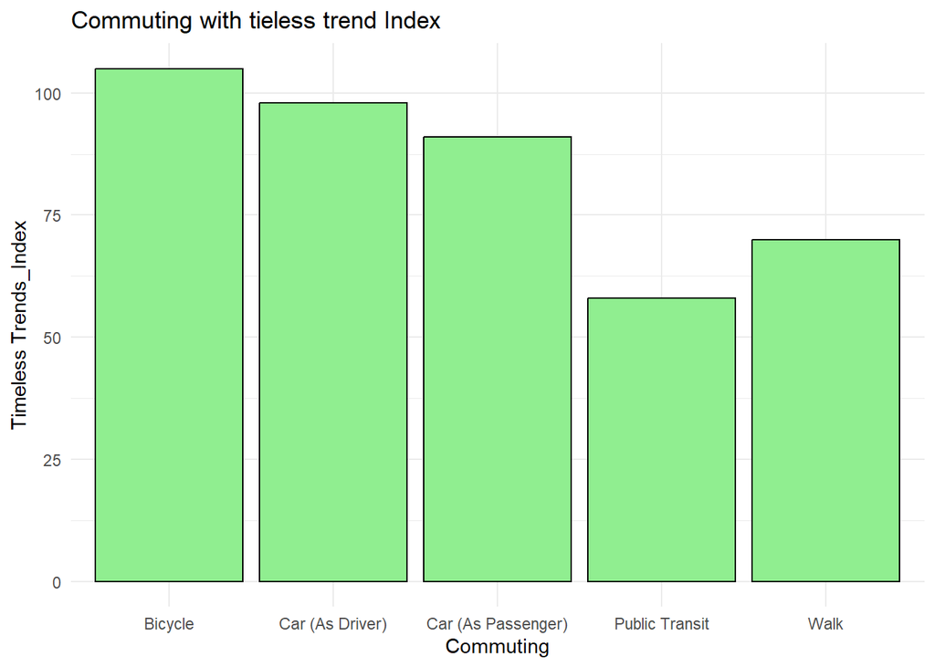

```r
#Created a dataset based on ways of travel
Commuting<-filter(envronics,Features %in% c("Car (As Driver)",
                                            "Car (As Passenger)",
                                            "Public Transit",
                                            "Walk",
                                            "Bicycle"
))
#From plot Person who is traveling with bicycle is showing higher Timeless Trend index
ggplot(Commuting, aes(x=Features,y=`Timeless Trends_Index`)) +
  geom_col(fill = "lightgreen", color = "black") +
  labs(title = "Commuting with tieless trend Index",
      x = "Commuting")+
  #    y = "Passenger Count")
  theme_minimal()
```

```r
#count of Timeless trend index having more than average value in this group is listed
More_than_avg_commuting<-sum(Commuting$`Timeless Trends_Index`>100)
print(More_than_avg_commuting)
```

```
## [1] 1
```

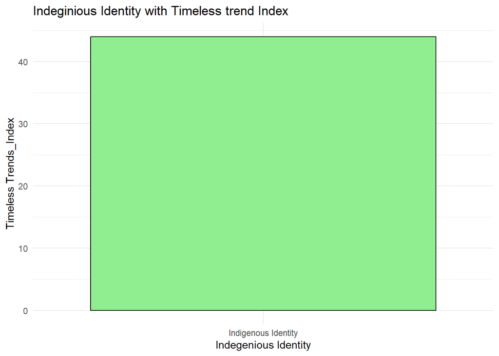

```r
#Created a dataset with Indigenious Identity details
Indigenous_Identity<-filter(envronics,Features %in% c("Indigenous Identity"))
#Timeless trend index is less even bellow 50
ggplot(Indigenous_Identity, aes(x=Features,y=`Timeless Trends_Index`)) +
  geom_col(fill = "lightgreen", color = "black") +
  labs(title = "Indeginious Identity with Timeless trend Index",
   x = "Indegenious Identity")+
  #    y = "Passenger Count")
  theme_minimal()
```

```r
#count of Timeless trend index having more than average value in this group is listed
More_than_avg_Indigenious<-sum(Indigenous_Identity$`Timeless Trends_Index`>100)
print(More_than_avg_Indigenious)
```

```
## [1] NA
```

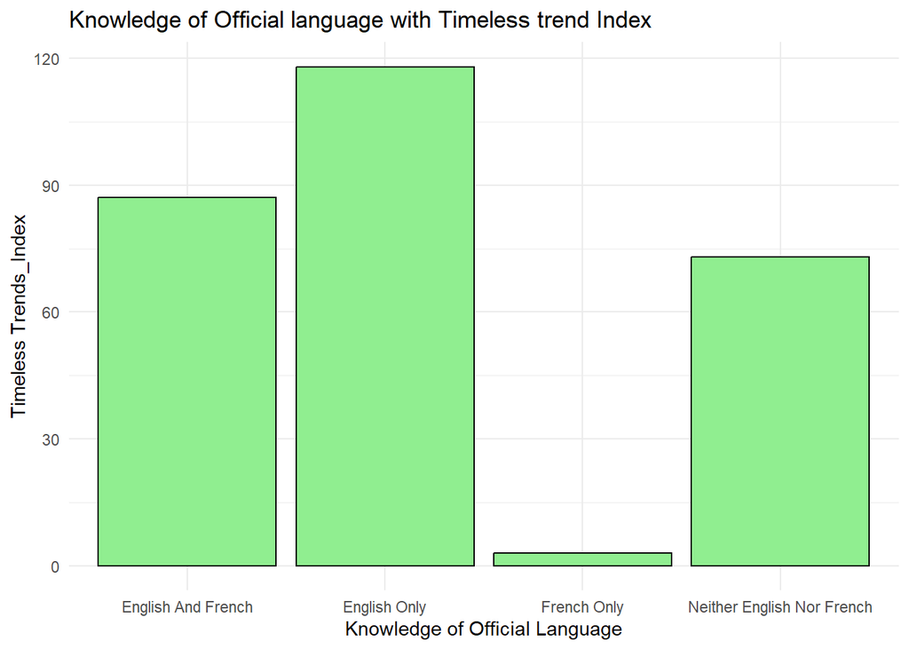

```r
#Created a dataset with Knowledge of Official Language
Knowledge_of_Official_Language<-filter(envronics,Features %in% c("English Only",
                                                                 "French Only",
                                                                 "English And French",
                                                                 "Neither English Nor French"
))
#From plot we can see like person having English only having high index
ggplot(Knowledge_of_Official_Language, aes(x=Features,y=`Timeless Trends_Index`)) +
  geom_col(fill = "lightgreen", color = "black") +
  labs(title = "Knowledge of Official language with Timeless trend Index",
      x = "Knowledge of Official Language")+
  #    y = "Passenger Count")
  theme_minimal()
```

```r
#count of Timeless trend index having more than average value in this group is listed
More_than_avg_Knowlege_of_official_Language<-sum(Knowledge_of_Official_Language>100)
print(More_than_avg_Knowlege_of_official_Language)
```

```
## [1] 47
```

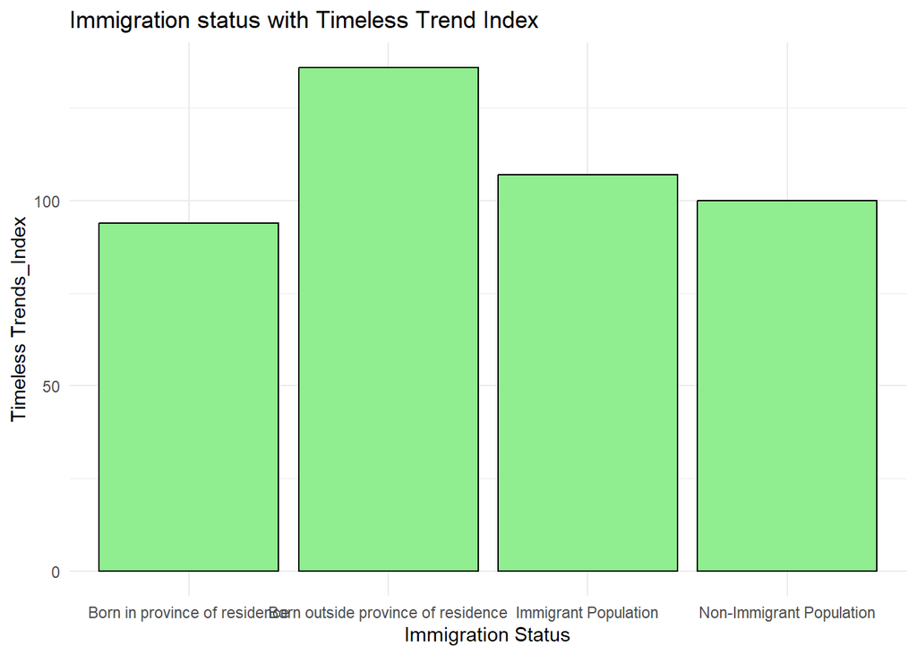

```r
#Created a dataset with Immigration status details
Immigration_Status<-filter(envronics,Features %in% c("Non-Immigrant Population",
                                                     "Born in province of residence",
                                                     "Born outside province of residence",
                                                     "Immigrant Population"
))
# from plot we can see Born outside province of residence is having higher Timeless Trend Index.
ggplot(Immigration_Status, aes(x=Features,y=`Timeless Trends_Index`)) +
  geom_col(fill = "lightgreen", color = "black") +
  labs(title = "Immigration status with Timeless Trend Index",
       x = "Immigration Status")+
  #    y = "Passenger Count")
  theme_minimal()
```

```r
#count of Timeless trend index having more than average value in this group is listed
More_than_avg_Immigration_status<- sum(Immigration_Status$`Timeless Trends_Index`)
print(More_than_avg_Immigration_status)
```

```
## [1] 437
```

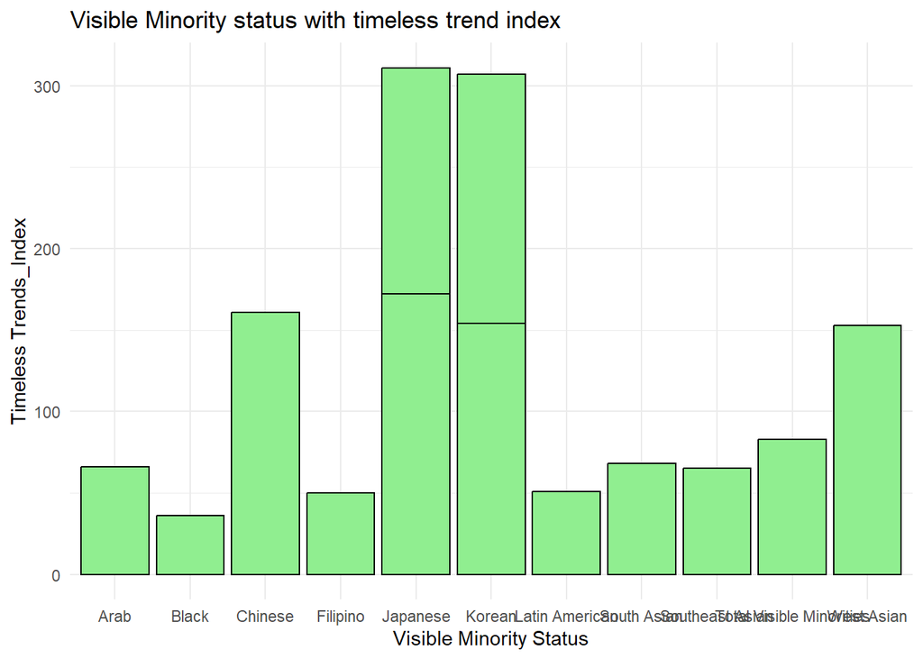

```r
#Created a dataset with Visible minority status
Visible_Minority_Status<-filter(envronics,Features %in% c("Total Visible Minorities",
                                                          "Chinese",
                                                          "South Asian",
                                                          "Black",
                                                          "Filipino",
                                                          "Latin American",
                                                          "Southeast Asian",
                                                          "Arab",
                                                          "West Asian",
                                                          "Korean",
                                                          "Japanese"
))
#Japenese and Korean is having highest Timeless Trend Index as based on plot
ggplot(Visible_Minority_Status, aes(x=Features,y=`Timeless Trends_Index`)) +
  geom_col(fill = "lightgreen", color = "black") +
  labs(title = "Visible Minority status with timeless trend index",
       x = "Visible Minority Status")+
  #    y = "Passenger Count")
  theme_minimal()
```

```r
#count of Timeless trend index having more than average value in this group is listed
More_than_avg_visible_minority<-sum(Visible_Minority_Status>100)
print(More_than_avg_visible_minority)
```

```
## [1] 181
```

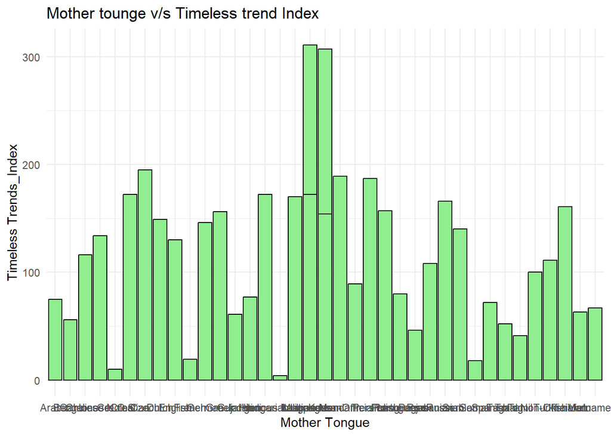

```r
#Created a graph based on mother tounge
Mother_Tongue<-filter(envronics,Features %in% c("English",
                                                "French",
                                                "Total Non-Official",
                                                "Italian",
                                                "German",
                                                "Punjabi",
                                                "Cantonese",
                                                "Spanish",
                                                "Arabic",
                                                "Tagalog",
                                                "Portuguese",
                                                "Polish",
                                                "Mandarin",
                                                "Chinese N.O.S",
                                                "Urdu",
                                                "Vietnamese",
                                                "Ukrainian",
                                                "Persian",
                                                "Russian",
                                                "Dutch",
                                                "Korean",
                                                "Greek",
                                                "Tamil",
                                                "Gujarati",
                                                "Romanian",
                                                "Hindi",
                                                "Hungarian",
                                                "Croatian",
                                                "Creoles",
                                                "Serbian",
                                                "Bengali",
                                                "Japanese",
                                                "Turkish",
                                                "Czech",
                                                "Somali",
                                                "Indigenous Languages",
                                               "Multiple Non-Official Languages"
))
#Based on the plot Japenese and Korean speaking people have highest Timeless Trend Index
ggplot(Mother_Tongue, aes(x=Features,y=`Timeless Trends_Index`)) +
  geom_col(fill = "lightgreen", color = "black") +
  labs(title = "Mother tounge v/s Timeless trend Index",
      x = "Mother Tongue")+
  #    y = "Passenger Count")
  theme_minimal()
```

```r
#count of Timeless trend index having more than average value in this group is listed
More_than_avg_Mother_Tongue<-sum(Mother_Tongue$`Timeless Trends_Index`>100)
print(More_than_avg_Mother_Tongue)
```

```
## [1] 22
```

```r
# Step 1: Select and clean clustering data
clustering_data1 <- envronics %>%
  select(Features,Timeless_Trends_Count,`Timeless Trends%`,`Timeless Trends% Pen`,`Timeless Trends_Index`)

# Step 2: Remove rows with NA/NaN/Inf
clustering_data1 <- clustering_data1[complete.cases(clustering_data1), ]
clustering_data1 <- clustering_data1[!apply(clustering_data1, 1, function(row) any(is.nan(row) | is.infinite(row))), ]

# Step 3: Extract numeric part and convert types
numeric_data <- clustering_data1 %>%
  select(-Features) %>%
  mutate_all(~as.numeric(as.character(.)))  # In case some are factors
anyNA(numeric_data)                     # Checks for NA
```

```
## [1] TRUE
```

```r
any(is.nan(as.matrix(numeric_data)))   # Checks for NaN
```

```
## [1] FALSE
```

```r
any(is.infinite(as.matrix(numeric_data)))
```

```
## [1] FALSE
```

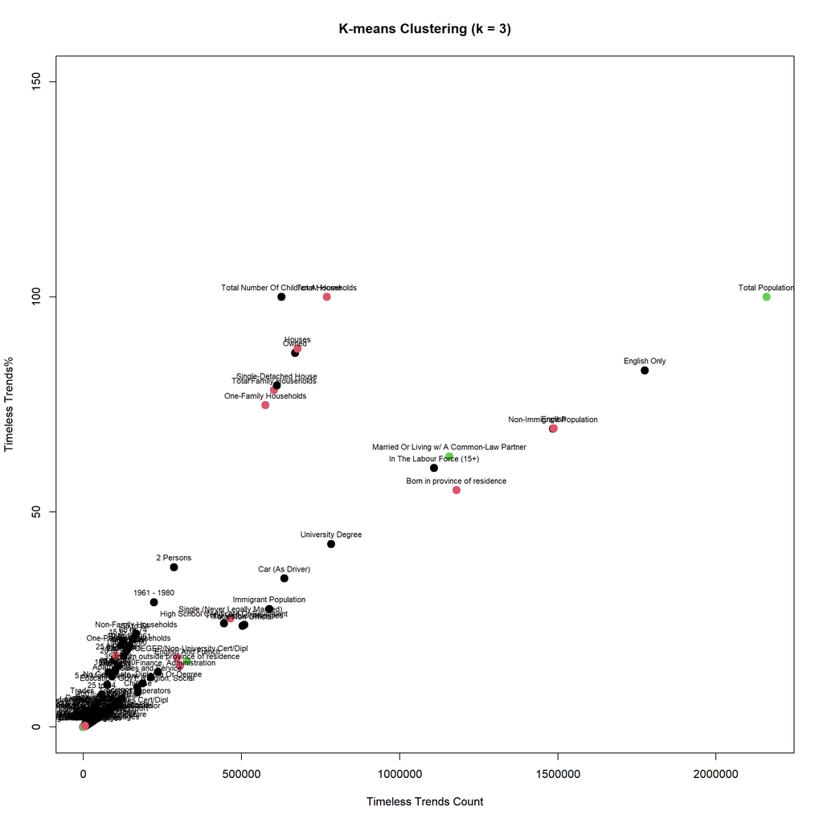

```r
numeric_data_clean <- numeric_data[complete.cases(numeric_data), ]


# Step 4: KMeans clustering
kmeans.result <- kmeans(numeric_data_clean, centers = 3)

# Step 5: Combine everything cleanly
clustering_result <- clustering_data1
#clustering_result$Cluster <- as.factor(kmeans.result$cluster)

plot(numeric_data$Timeless_Trends_Count, numeric_data$`Timeless Trends%`,
     col = kmeans.result$cluster,
     pch = 19, cex = 1.5,
     xlab = "Timeless Trends Count",
     ylab = "Timeless Trends%",
     main = "K-means Clustering (k = 3)",
     ylim= c(0,150))

# Add labels
text(numeric_data$Timeless_Trends_Count, numeric_data$`Timeless Trends%`,
     labels = clustering_data1$Features, pos = 3, cex = 0.7)
```

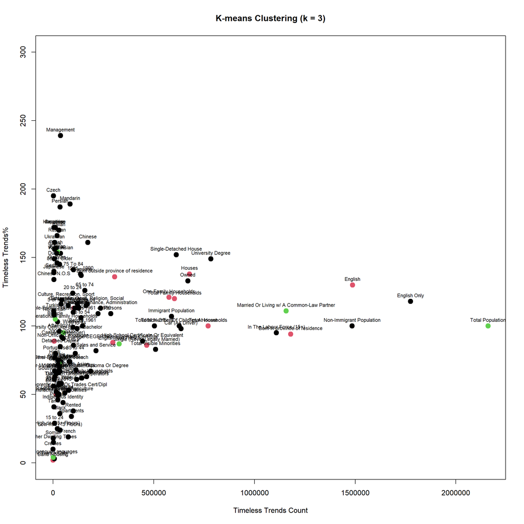

```r
plot(numeric_data$Timeless_Trends_Count, numeric_data$`Timeless Trends_Index`,
     col = kmeans.result$cluster,
     pch = 19, cex = 1.5,
     xlab = "Timeless Trends Count",
     ylab = "Timeless Trends%",
     main = "K-means Clustering (k = 3)",
     ylim= c(0,300))

# Add labels
text(numeric_data$Timeless_Trends_Count, numeric_data$`Timeless Trends_Index`,
     labels = clustering_data1$Features, pos = 3, cex = 0.7)
```

##From the above study we could find like

-We could see like Management people,Czech people,Mandreain speaking people,persian people,japenese and Korean speaking people having highest Timeless Trend Index

_ people born outside province of residence and people speaks only english have high Timeless trend Index

_ Person who is travelling with bycycle and/or having University degree has high Timeless trend Index

- Housing period of construction around 1980-90 have highest index
- 85 or Older is having higher Index and we can also see the trend of increasing Timeless tend index with age
- 1 family house hold, 4 members, married or living with a common low partner,who owned the house, with children at home age 20-24
- Single detached house

-We should traget on these groups of people and tried to attract them with good deals, attracting shoping materials

## 1.2 Retention Stratergy:

#Using Kmeans clustering I had creaed clusters with similar charcheterstics. - It need more study on what are their common charachterstics

- Based on than we can do marketing each of the cluster similarly.

_ We should concentrate on Features with Timeless Index low or bellow average

_ I am not able to list all the details I get from the study, but most important ones.